# R Notebook

```r
library(camprotR)
library(MSnbase)
library(ggplot2)
library(tidyr)
library(dplyr)
library(here)
library(limma)
library(uniprotREST)
```

```r
total <- readRDS(here('results/total.rds'))
phospho_sites <- readRDS(here('results/phospho_sites.rds'))
```

Below, we identify the total peptides that overlap each phosphosite. Note that each phosphosite may intersect multiple total peptides (due to missed cleavages) and each total peptide may intersect multiple phosphosites (due to multiple phosphosites per peptide). The code chunk takes a while to run..

```r
phospho_f <- phospho_sites %>% fData() %>% tibble::rownames_to_column('ID')
total_f <- total %>% fData() %>% tibble::rownames_to_column('ID')

phospho_peptide_to_total_peptides <- vector('list', length=length(phospho_f$ID))
names(phospho_peptide_to_total_peptides) <- phospho_f$ID
n <- 0
for(phospho_id in phospho_f$ID){
  row <- phospho_f %>% filter(ID==phospho_id)

  n <- n + 1
  ptm_positions <- as.numeric(strsplit(row$ptm_position, split='\\|')[[1]])

  total_peptide_ids <- total_f %>%
    filter(Master.Protein.Accessions %in% row$Master.Protein.Accessions,
           peptide_start<=min(ptm_positions),
           peptide_end>=max(ptm_positions)) %>%
    pull(ID)

  phospho_peptide_to_total_peptides[[ row$ID]] <- total_peptide_ids
}
```

Now, how many overlapping features. Note that for the phospho and total to be considered intersecting, there must be at least one total peptide which overlaps the phosphosite. Out of the 666 phosphosites, only 107 have at least one overlapping total peptide.

```r
print(length(phospho_f$ID))
```

```
[1] 666
```

```r
print(length(phospho_peptide_to_total_peptides))
```

```
[1] 666
```

```r
print(table(sapply(phospho_peptide_to_total_peptides, function(x) length(x)>0)))
```

```
FALSE  TRUE
  559   107
```

```r
print(table(sapply(phospho_peptide_to_total_peptides, length)))
```

```
  0   1   2   3
559  95  11   1
```

limma requires a single row per feature with a columns per sample. Here, the phospho and total are separate samples so we need to combine them into a single row.

```r
combined_exprs <- phospho_peptide_to_total_peptides %>% names() %>% lapply(function(x){
  total_peptides <- phospho_peptide_to_total_peptides[[x]]

  if(length(total_peptides)>0) {
    exprs_values <- c(exprs(phospho_sites[x,]),
                      colSums(exprs(total[total_peptides,]), na.rm=TRUE))
    exprs_values <- unname(exprs_values)
    return(exprs_values)
  } else { return(NULL) }
})
names(combined_exprs) <- names(phospho_peptide_to_total_peptides)
```

Create the completed matrix of phospho and total.

```r
combined_exprs <- combined_exprs[sapply(combined_exprs, function(x) !is.null(x))]
all_combined_exprs <- bind_rows(combined_exprs) %>% t() %>% as.matrix

rownames(all_combined_exprs) <- names(combined_exprs)

colnames(all_combined_exprs) <- c(paste0(colnames(phospho_sites), '_phospho'),
                                  paste0(colnames(total), '_total'))
```

Inspect the combined quantification matrix.

```r
head(all_combined_exprs) #
```

```
                   126_phospho 127N_phospho 127C_phospho 128N_phospho 128C_phospho 129N_phospho 129C_phospho 130N_phospho 130C_phospho 131_phospho 126_total 127N_total 127C_total 128N_total 128C_total
O00499_296|298|303       481.9        476.6        474.9        431.4        338.5        373.1        314.4        342.0        333.7       335.6      59.2       53.2       65.7       51.6       58.4
O14639_452|455           246.2        231.8        246.9        236.5        175.9        184.5        167.9        181.8        173.5       170.9     108.2      113.9      111.5      106.3      106.0
O60841_113                86.1         84.5         89.5         72.5         70.5         68.8         47.7         76.9         70.0        66.6      91.4       79.0       95.6      100.0       94.1
O60841_164               320.5        308.4        291.1        275.6        229.5        249.1        239.9        246.6        236.5       277.4       7.6       10.4       11.5       11.5       11.7
O60841_214               718.1        661.7        708.4        611.4        473.7        537.8        456.4        526.5        518.8       504.3      70.2       65.3       77.1       62.8       68.6
O75554_258|262           490.5        475.2        497.3        414.3        327.8        350.0        335.4        362.6        324.9       355.0      80.2       76.0       87.4       65.7       71.0
                   129N_total 129C_total 130N_total 130C_total 131_total
O00499_296|298|303       68.3       50.5       45.0       54.4      47.1
O14639_452|455          122.4       86.0       79.0       91.8      89.0
O60841_113               91.2       89.9       84.0       75.7      81.4
O60841_164                8.8        9.7        8.2        7.4      12.7
O60841_214               67.3       60.1       53.6       63.7      56.5
O75554_258|262           88.9       78.3       76.5       81.6     102.5
```

```r
all_combined_fdata <- fData(phospho_sites[rownames(all_combined_exprs),])[
  ,c('Master.Protein.Accessions', 'ptm_position')]
all_combined_fdata$n_total <- sapply(rownames(all_combined_exprs),
                                     function(x) length(phospho_peptide_to_total_peptides[[x]]))

all_combined_pdata <- rbind((pData(phospho_sites) %>% mutate(type='phospho')),
                            (pData(total) %>% mutate(type='total')))
rownames(all_combined_pdata) <- colnames(all_combined_exprs)
all_combined_res <- MSnSet(as.matrix.data.frame(all_combined_exprs),
                           all_combined_fdata,
                           all_combined_pdata)

head(fData(all_combined_res))
```

|  | Master.Protein.Accessions | ptm_position | n_total |
| --- | --- | --- | --- |
| O00499_296\|298\|303 | O00499 | 296\|298\|303 | 1 |
| O14639_452\|455 | O14639 | 452\|455 | 1 |
| O60841_113 | O60841 | 113 | 1 |
| O60841_164 | O60841 | 164 | 1 |
| O60841_214 | O60841 | 214 | 1 |
| O75554_258\|262 | O75554 | 258\|262 | 1 |

```r
pData(all_combined_res)
```

|  | spike | condition | type |
| --- | --- | --- | --- |
| 126_phospho | x1 | 1 | phospho |
| 127N_phospho | x1 | 1 | phospho |
| 127C_phospho | x1 | 1 | phospho |
| 128N_phospho | x1 | 1 | phospho |
| 128C_phospho | x6 | 2 | phospho |
| 129N_phospho | x6 | 2 | phospho |
| 129C_phospho | x6 | 2 | phospho |
| 130N_phospho | x6 | 3 | phospho |
| 130C_phospho | x6 | 3 | phospho |
| 131_phospho | x6 | 3 | phospho |

[output cut: 10 more lines]

Below, we subset to the first 2 ‘conditions’, where condition 1 = tags 1-4 (x1 phospho; x1 total) and condition 2 = tags 5-7 (x6 phospho; x2 total). The ground truth for the difference between the first 4 tags and the next 3 is therefore a 3-fold increase in phosphorylation for the yeast proteins and reduced phosphorylation for the human proteins. For the human proteins, given the amounts of spike in yeast and balancing human proteins to make up the labelled material, we expect a 30% drop in phosphorylation.

```r
pairwise_comparison_combined_res <- all_combined_res[,pData(all_combined_res)$condition %in% 1:2]
pData(pairwise_comparison_combined_res)
```

|  | spike | condition | type |
| --- | --- | --- | --- |
| 126_phospho | x1 | 1 | phospho |
| 127N_phospho | x1 | 1 | phospho |
| 127C_phospho | x1 | 1 | phospho |
| 128N_phospho | x1 | 1 | phospho |
| 128C_phospho | x6 | 2 | phospho |
| 129N_phospho | x6 | 2 | phospho |
| 129C_phospho | x6 | 2 | phospho |
| 126_total | x1 | 1 | total |
| 127N_total | x1 | 1 | total |
| 127C_total | x1 | 1 | total |

[output cut: 4 more lines]

Below, we perform the limma analysis

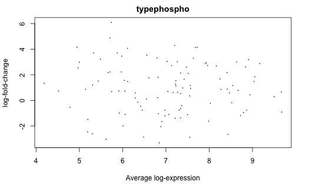

```r
dat <- exprs(pairwise_comparison_combined_res) %>% log(base=2)

type <- factor(pData(pairwise_comparison_combined_res)$type, level=c('total', 'phospho'))
condition <- factor(pData(pairwise_comparison_combined_res)$condition, levels=1:2)

study.design <- model.matrix(~type*condition)

fit <- lmFit(dat, study.design)
fit <- eBayes(fit, trend=TRUE)

plotMA(fit, coef=2)
```

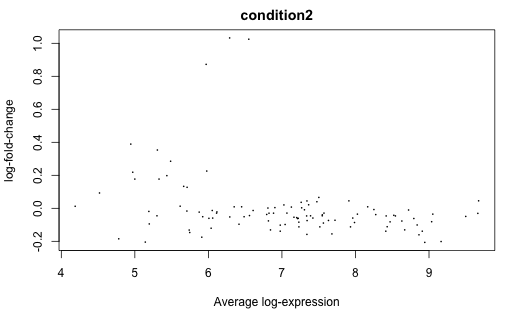

```r
plotMA(fit, coef=3)
```

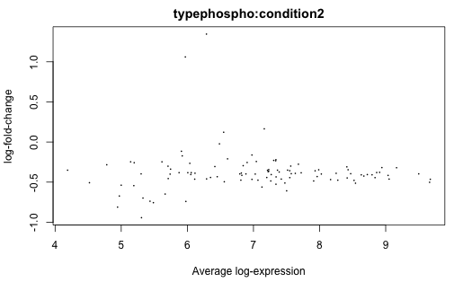

```r
plotMA(fit, coef=4)
```

```r
limma.results <- topTable(fit, coef = colnames(fit$coefficients)[4], n = Inf, confint=TRUE)
limma.results$sigma <- fit$sigma
```

We would like to add information about the species to make sure the fold-changes are in the expected direction

```r
limma.results$protein <- rownames(limma.results) %>%
  strsplit(split='_') %>%
  sapply('[[', 1)

species_res <-  uniprot_map(
  ids = unique(limma.results$protein),
  from = "UniProtKB_AC-ID",
  to = "UniProtKB",
  fields = "organism_name") %>%
  mutate(species=recode(Organism,
                        "Saccharomyces cerevisiae (strain ATCC 204508 / S288c) (Baker's yeast)"="S.cerevisiae",
                        "Homo sapiens (Human)"="H.sapiens"))
```

```
Job ID: ea3205dfeb2e33b7529b68ba58a550f55cabc604
Page 1 of 1
Success
```

[figure not shown]

OK, so the direction of change is as expected (reduced for human, increased for yeast), but only a subset of the fold-changes reach a 1% FDR threshold for significance.